# BMIN503/EPID600 Project Template

Anahita Davoudi

### Overview

This project uses the publicly available MIMIC-III ICU dataset to study the characteristics of the patients admitted to the Beth Israel Deaconess Medical Center under the category of Thrombotic events. This dataset has been developed by MIT and published around over 60,000 intensive care unit hospitalizations. This dataset includes demographics, vital signs, laboratory tests, medications, and other structured and unstructured data.

Three faculty/staff have been consulted for the definition of the project: - Danielle Mowery: Assistant Professor; Department of Biostatistics, Epidemiology, and Informatics - Emily Schriver: Clinical Informaticist; Data Analytic Center - Sy Hwang: NLP data scientist/programmer; IBI Clinical Research Informatics Core

### Introduction

The thrombotic events have got attention due to COVID-19 recently. The thrombogenicity of COVID-19 has been detected by the high frequency of thrombotic events observed even in Covid-19 patients treated with anticoagulation. The thrombotic events hit every aspect of the circulatory system (e.g., multi-organ and multi-system). The clots can happen anywhere in the body, and we need a better way of identifying and classifying patients. We can achieve that by the qualitative characterizations of this data, looking at overlaps, and the different features between all categories of the thrombotic events.

We use a data-driven approach for subphenotyping of patients. Subphenotyoing can be quite challenging and very biased. For this project, we used exploratory data analysis and natural language processing methods to help extract features of patients identified by thrombotic events. We have used ICD9 codes to describe our subcohort of thrombotic events from MIMIC-III. We will examine the patterns seen in the two cohorts of thrombotic and bleeding.

### Methods

Required packages for the project:

```r
library(tm)
library(dplyr)
```

```r
library(ggplot2)
library(wordcloud)
library(RColorBrewer)
library(topicmodels)
library(tidyr)
library(tidyverse)
library(ggraph)
library(igraph)
library(stringr)
library(gtsummary)
library(tableone)
```

#### Importing data

List of input data from the MIMIC-III dataset:

```r
Admissions      <-  read.csv(file = 'ADMISSIONS.csv')
icdcodes        <- read.csv(file = 'DIAGNOSES_ICDs.csv')
#labs            <- read.csv(file = 'LABEVENTS.csv')
#micro           <- read.csv(file = 'MICROBIOLOGYEVENTS.csv')
prescriptions   <- read.csv(file = 'C:/Users/anahitad/thrombotic events/data/Pres.csv')
patients        <- read.csv(file = 'PATIENTS.csv')
notes           <- read.csv(file = 'NOTEEVENTSs.csv')
```

#### Data Cleaning

This section selects only relevant information from Admissions, Diagnoses (ICD codes), Patients, Note events, lab events, prescriptions, labs, and micro tables.

##### Predefined ICD9 Codes

A set of specific ICD9 codes are presented for the two category of thrombotic and bleeding.We also used some specific keywords to filter out the notes that are more related to these two categories.

```r
synonyms_bleeding = c("bleeding", "haemorrhage", "haemorrhages", "hemorrhage", "hemorrhages", "hemorrhagic", "bleed", "ruptured", "aneurysm",

"aneurysms", "annurysum", "annurysums", "aneurism", "aneurisms", "hematoma", "hematomas")

synonyms_thrombosis = c("thrombosis", "thrombotic", "thrombi", "blood clot", "blood clots", "clot", "clots", "ischemia", "ischemic", "infarction", "infarctions", "infraction", "infractions", "embolism", "embolisms", "embolus", "emboli", "embolic")

icd_thrombotics <- c("452", "4358", "4359", "4536", "4532", "4533", "4510", "36234", "41071", "41091", "41181", "41512", "42979", "43391", "44409", "44481", "45351", "45386", "45382")

icd_bleeding <- c("430", "431", "4230", "4320", "4321", "4560", "5693", "5695", "5789", "37923", "42979", "53501", "53100", "53110", "53120", "53130", "53140", "53150", "53160", "53200", "53210", "53220", "53230", "53240", "53250", "53260", "53270", "53300", "53310", "53320", "53340", "53350", "53360", "53400", "53410", "53420", "53440", "53450", "53460", "56212", "56213", "56201", "56202", "56203", "72992", "56881")
```

##### Varible Selection

```r
#note_cat <- c("Discharge summary", "Radiology")
#notes_new <- subset(notes, CATEGORY %in% note_cat)
#note_new_clipped <- notes_new[,which(colnames(notes_new) %in% c("ROW_ID", "SUBJECT_ID", "HADM_ID", "CATEGORY", "TEXT"))]
#icdcode_clipped <- icdcodes[,which(colnames(icdcodes) %in% c("ROW_ID", "SUBJECT_ID", "HADM_ID", "ICD9_CODE"))]

out_thrombo <- filter(notes, str_detect(TEXT, paste(synonyms_thrombosis, collapse="|")))
out_bleed <- filter(notes, str_detect(TEXT, paste(synonyms_bleeding, collapse="|")))
newicd_thrombo <- subset(icdcodes, ICD9_CODE %in% icd_thrombotics)
newicd_bleed <- subset(icdcodes, ICD9_CODE %in% icd_bleeding)
```

#### Joining Tables

```r
# join all tables except the notes: patients, ICD codes, prescriptions, admission
#add a column that is showing this is thrombotic called Event with two levels (Thrombotic) and Bleeding
#calculate age and los


summary_thrombo <- list(Admissions, prescriptions, newicd_thrombo) %>% reduce(inner_join, by = c("SUBJECT_ID", "HADM_ID"))
all_summary_thrombo <- inner_join(x = summary_thrombo, y = patients, by = "SUBJECT_ID")
all_summary_thrombo$ADMITTIME = as.POSIXlt(as.character(all_summary_thrombo$ADMITTIME), format = "%Y-%m-%d %H:%M:%S")
all_summary_thrombo$DISCHTIME = as.POSIXlt(as.character(all_summary_thrombo$DISCHTIME), format = "%Y-%m-%d %H:%M:%S")
all_summary_thrombo$DOB = as.POSIXlt(as.character(all_summary_thrombo$DOB), format = "%Y-%m-%d %H:%M:%S")
all_summary_thrombo$LOS = difftime( all_summary_thrombo$DISCHTIME, all_summary_thrombo$ADMITTIME, units = "days")
all_summary_thrombo$LOS = as.numeric(all_summary_thrombo$LOS)
all_summary_thrombo$AGE = difftime(all_summary_thrombo$ADMITTIME, all_summary_thrombo$DOB, units = "days")/365
all_summary_thrombo$AGE = as.numeric(all_summary_thrombo$AGE)
all_summary_thrombo <- all_summary_thrombo %>% add_column(Event = 'Thrombotic', .before = "ADMISSION_TYPE")



summary_bleed <- list(Admissions, prescriptions, newicd_bleed) %>% reduce(inner_join, by = c("SUBJECT_ID", "HADM_ID"))
all_summary_bleed <- inner_join(x = summary_bleed, y = patients, by = "SUBJECT_ID")
all_summary_bleed$ADMITTIME = as.POSIXlt(as.character(all_summary_bleed$ADMITTIME), format = "%Y-%m-%d %H:%M:%S")
all_summary_bleed$DISCHTIME = as.POSIXlt(as.character(all_summary_bleed$DISCHTIME), format = "%Y-%m-%d %H:%M:%S")
all_summary_bleed$DOB = as.POSIXlt(as.character(all_summary_bleed$DOB), format = "%Y-%m-%d %H:%M:%S")
all_summary_bleed$LOS = difftime( all_summary_bleed$DISCHTIME, all_summary_bleed$ADMITTIME, units = "days")
all_summary_bleed$LOS = as.numeric(all_summary_bleed$LOS)
all_summary_bleed$AGE = difftime( all_summary_bleed$ADMITTIME, all_summary_bleed$DOB, units = "days")/365
all_summary_bleed$AGE = as.numeric(all_summary_bleed$AGE)
all_summary_bleed <- all_summary_bleed %>% add_column(Event = 'Bleeding', .before = "ADMISSION_TYPE")


# combining two data

all_data <- rbind(all_summary_thrombo,all_summary_bleed)
all_table_data <- all_data[,which(colnames(all_data) %in% c("SUBJECT_ID", "HADM_ID", "Event", "ADMISSION_TYPE", "ADMISSION_LOCATION", "DISCHARGE_LOCATION", "INSURANCE",  "MARITAL_STATUS", "ETHNICITY", "HOSPITAL_EXPIRE_FLAG", "DRUG_TYPE", "DRUG", "ICD9_CODE", "LOS", "GENDER", "AGE", "DIAGNOSIS"))]

# if there are repeated rows then:

U_all_table_data <- unique(all_table_data)

# conver characters to factor and numbers to numeric



changed_data <- U_all_table_data

#if a name of a drug has been repeated less than 500 times


#for each drug name if it has been repeated less than 500 times then change it to "Other"



changed_data %>% tbl_summary(by = Event, missing = "no",) %>%
  modify_header(label = "**Characteristic**") %>%
  bold_labels() %>%
  add_p()
```

[output not shown]

[output not shown]

[output not shown]

| **Characteristic** | **Bleeding**, N = 189,848<sup>1</sup> | **Thrombotic**, N = 168,991<sup>1</sup> | **p-value**<sup>2</sup> |
| --- | --- | --- | --- |
| SUBJECT_ID | 31,639 (16,943, 67,480) | 27,239 (13,780, 62,308) | <0.001 |
| HADM_ID | 151,734 (125,598, 176,267) | 151,224 (125,899, 176,708) | <0.001 |
| ADMISSION_TYPE |  |  | <0.001 |
| ELECTIVE | 7,050 (3.7%) | 8,060 (4.8%) |  |
| EMERGENCY | 180,244 (95%) | 157,107 (93%) |  |
| NEWBORN | 83 (<0.1%) | 81 (<0.1%) |  |
| URGENT | 2,471 (1.3%) | 3,743 (2.2%) |  |
| ADMISSION_LOCATION |  |  | <0.001 |
| ** INFO NOT AVAILABLE ** | 0 (0%) | 46 (<0.1%) |  |
| CLINIC REFERRAL/PREMATURE | 49,453 (26%) | 29,542 (17%) |  |
| EMERGENCY ROOM ADMIT | 99,478 (52%) | 62,463 (37%) |  |
| PHYS REFERRAL/NORMAL DELI | 10,524 (5.5%) | 12,790 (7.6%) |  |
| TRANSFER FROM HOSP/EXTRAM | 29,254 (15%) | 63,458 (38%) |  |
| TRANSFER FROM OTHER HEALT | 267 (0.1%) | 81 (<0.1%) |  |
| TRANSFER FROM SKILLED NUR | 872 (0.5%) | 611 (0.4%) |  |
| DISCHARGE_LOCATION |  |  | <0.001 |
| DEAD/EXPIRED | 38,682 (20%) | 28,024 (17%) |  |
| DISC-TRAN CANCER/CHLDRN H | 105 (<0.1%) | 79 (<0.1%) |  |
| DISC-TRAN TO FEDERAL HC | 53 (<0.1%) | 0 (0%) |  |
| DISCH-TRAN TO PSYCH HOSP | 401 (0.2%) | 191 (0.1%) |  |
| HOME | 32,137 (17%) | 21,678 (13%) |  |
| HOME HEALTH CARE | 27,098 (14%) | 43,866 (26%) |  |
| HOME WITH HOME IV PROVIDR | 0 (0%) | 85 (<0.1%) |  |
| HOSPICE-HOME | 1,746 (0.9%) | 1,198 (0.7%) |  |
| HOSPICE-MEDICAL FACILITY | 1,415 (0.7%) | 720 (0.4%) |  |
| ICF | 41 (<0.1%) | 25 (<0.1%) |  |
| LEFT AGAINST MEDICAL ADVI | 444 (0.2%) | 436 (0.3%) |  |
| LONG TERM CARE HOSPITAL | 18,173 (9.6%) | 12,351 (7.3%) |  |
| OTHER FACILITY | 265 (0.1%) | 180 (0.1%) |  |
| REHAB/DISTINCT PART HOSP | 40,973 (22%) | 25,909 (15%) |  |

[output cut: 5093 more lines]

```r
# cluster based on drugs? group based on drugs? chi-square test? association test? something here!


# original nymber of drugs btween two groups: 2326
```

```r
demo_data = all_table_data[!duplicated(all_table_data[,'SUBJECT_ID']),]
dim(demo_data)
```

```
## [1] 7742   17
```

```r
# drug type figure

# U_all_table_data %>% ggplot(aes(x = Event, fill=DRUG_TYPE)) + geom_bar(position='dodge')


# another figure for top 5 drugs for each event in same figure maybe? or separate?



# another figure shows the distributions of the ICD9 codes beside each other for each event separate
```

#### Data Summary - Thrombotic Events

```r
# Figures here for both thrombotic and bleeding beside each other ...

#Drug name categories: Any drugs that had less than 1000 in any of the bleeding or thrombotics has been categorized as other which reduced the number of drugs from 2326 to 160.  no actually to 29 (when doing unique stuff).

xxx = demo_data[,which(colnames(demo_data) %in% c("AGE","GENDER",  "ETHNICITY","INSURANCE","ADMISSION_TYPE","Event"))]

other_ethnicity <- c("AMERICAN INDIAN/ALASKA NATIVE", "AMERICAN INDIAN/ALASKA NATIVE FEDERALLY RECOGNIZED TRIBE", "CARIBBEAN ISLAND", "MULTI RACE ETHNICITY", "OTHER",
"UNABLE TO OBTAIN", "UNKNOWN/NOT SPECIFIED", "PATIENT DECLINED TO ANSWER", "NATIVE HAWAIIAN OR OTHER PACIFIC ISLANDER", "PORTUGUESE")

ASIAN <- c("ASIAN", "ASIAN - ASIAN INDIAN", "ASIAN - CAMBODIAN", "ASIAN - CHINESE", "ASIAN - FILIPINO", "ASIAN - JAPANESE", "ASIAN - KOREAN", "ASIAN - OTHER", "ASIAN - THAI", "ASIAN - VIETNAMESE")

WHITE <- c("WHITE", "WHITE - BRAZILIAN", "WHITE - EASTERN EUROPEAN", "WHITE - OTHER EUROPEAN", "WHITE - RUSSIAN", "MIDDLE EASTERN")

BLACK <- c("BLACK/AFRICAN", "BLACK/AFRICAN AMERICAN", "BLACK/CAPE VERDEAN", "BLACK/HAITIAN")

HISPANIC <- c("HISPANIC OR LATINO", "HISPANIC/LATINO - COLOMBIAN", "HISPANIC/LATINO - CUBAN", "HISPANIC/LATINO - DOMINICAN", "HISPANIC/LATINO - GUATEMALAN", "HISPANIC/LATINO - PUERTO RICAN", "HISPANIC/LATINO - SALVADORAN")

xxx <- xxx %>% mutate(ETHNICITY = case_when(ETHNICITY %in% ASIAN ~ "ASIAN", ETHNICITY %in% WHITE ~ "WHITE", ETHNICITY %in% BLACK ~ "BLACK", ETHNICITY %in% HISPANIC ~ "HISPANIC", ETHNICITY %in% other_ethnicity ~ "OTHER"))


# Age over 100 change to NA since the de-identification process made the age variable abnormal here

xxx$AGE = ifelse(xxx$AGE>100, NA, xxx$AGE)

xxx %>% tbl_summary(by = Event) %>%
  modify_header(label = "**Characteristic**") %>%
  bold_labels() %>%
  add_p() %>%  add_overall()
```

| **Characteristic** | **Overall**, N = 7,742<sup>1</sup> | **Bleeding**, N = 4,187<sup>1</sup> | **Thrombotic**, N = 3,555<sup>1</sup> | **p-value**<sup>2</sup> |
| --- | --- | --- | --- | --- |
| ADMISSION_TYPE |  |  |  | <0.001 |
| ELECTIVE | 263 (3.4%) | 112 (2.7%) | 151 (4.2%) |  |
| EMERGENCY | 7,349 (95%) | 4,023 (96%) | 3,326 (94%) |  |
| NEWBORN | 5 (<0.1%) | 3 (<0.1%) | 2 (<0.1%) |  |
| URGENT | 125 (1.6%) | 49 (1.2%) | 76 (2.1%) |  |
| INSURANCE |  |  |  | <0.001 |
| Government | 189 (2.4%) | 116 (2.8%) | 73 (2.1%) |  |
| Medicaid | 524 (6.8%) | 330 (7.9%) | 194 (5.5%) |  |
| Medicare | 4,836 (62%) | 2,432 (58%) | 2,404 (68%) |  |
| Private | 2,107 (27%) | 1,258 (30%) | 849 (24%) |  |
| Self Pay | 86 (1.1%) | 51 (1.2%) | 35 (1.0%) |  |
| ETHNICITY |  |  |  | <0.001 |
| ASIAN | 218 (2.8%) | 150 (3.6%) | 68 (1.9%) |  |
| BLACK | 615 (7.9%) | 393 (9.4%) | 222 (6.2%) |  |
| HISPANIC | 234 (3.0%) | 148 (3.5%) | 86 (2.4%) |  |
| OTHER | 986 (13%) | 419 (10%) | 567 (16%) |  |
| WHITE | 5,689 (73%) | 3,077 (73%) | 2,612 (73%) |  |
| GENDER |  |  |  | <0.001 |
| F | 3,415 (44%) | 1,924 (46%) | 1,491 (42%) |  |
| M | 4,327 (56%) | 2,263 (54%) | 2,064 (58%) |  |
| AGE | 69 (57, 79) | 67 (55, 79) | 71 (60, 79) | <0.001 |
| Unknown | 510 | 260 | 250 |  |

<sup>*1*</sup> Statistics presented: n (%); Median (IQR) <sup>*2*</sup> Statistical tests performed: Fisher's exact test; chi-square test of independence; Wilcoxon rank-sum test

```r
# looking at diagnosis


yyy <- unique(all_table_data)

zzz <- unique(yyy[c("DIAGNOSIS")])

synonyms_bleeding = c("bleeding", "haemorrhage", "haemorrhages", "hemorrhage", "hemorrhages", "hemorrhagic", "bleed", "ruptured", "aneurysm",

"aneurysms", "annurysum", "annurysums", "aneurism", "aneurisms", "hematoma", "hematomas")

synonyms_thrombosis = c("thrombosis", "thrombotic", "thrombi", "blood clot", "blood clots", "clot", "clots", "ischemia", "ischemic", "infarction", "infarctions", "infraction", "infractions", "embolism", "embolisms", "embolus", "emboli", "embolic")
```

# demoghrapic figures

```r
demo_data$DISCHARGE_LOCATION = ifelse(demo_data$DISCHARGE_LOCATION %in% c("HOME","HOME WITH HOME IV PROVIDR",'HOME HEALTH CARE',
                                                                          "LEFT AGAINST MEDICAL ADVI"), "HOME",
                                demo_data$DISCHARGE_LOCATION)
demo_data$DISCHARGE_LOCATION = ifelse(demo_data$DISCHARGE_LOCATION %in% c("HOSPICE-MEDICAL FACILITY","HOSPICE-HOME"), "HOSPICE",
                                demo_data$DISCHARGE_LOCATION)
demo_data$DISCHARGE_LOCATION = ifelse(demo_data$DISCHARGE_LOCATION %in% c("LONG TERM CARE HOSPITAL","SHORT TERM HOSPITAL",
                                                                          "REHAB/DISTINCT PART HOSP","DISCH-TRAN TO PSYCH HOSP",
                                                                          "DISC-TRAN CANCER/CHLDRN H"), "HOSPITAL",
                                demo_data$DISCHARGE_LOCATION)
demo_data$DISCHARGE_LOCATION = ifelse(demo_data$DISCHARGE_LOCATION %in% c("SNF","ICF","OTHER FACILITY","DISC-TRAN TO FEDERAL HC"), "Facility",
                                demo_data$DISCHARGE_LOCATION)
```

```r
box_age  = ggplot(demo_data, aes(x = Event, y = LOS))+
  geom_boxplot()
disch_data = array(dim = c(10, 3))
disch_data = as.data.frame(disch_data)
colnames(disch_data) = c("disch_location","Event","Number")
disch_names = unique(demo_data$DISCHARGE_LOCATION)
for(i in 1:5){
  disch_data$disch_location[i] = disch_names[i]
  disch_data$Event[i] = "Bleeding"
  disch_data$Number[i] = length(which(demo_data$Event=="Bleeding" & demo_data$DISCHARGE_LOCATION == disch_names[i]))
}


for(i in 1:5){
  disch_data$disch_location[i+5] = disch_names[i]
  disch_data$Event[i+5] = "Thrombotic"
  disch_data$Number[i+5] = length(which(demo_data$Event=="Thrombotic" & demo_data$DISCHARGE_LOCATION == disch_names[i]))
}

bar_disch = ggplot(disch_data, aes(x = Event, y = Number, fill = disch_location))+
  geom_bar(stat = 'identity', position = position_dodge())

## normalized version for discharge location
disch_data = array(dim = c(10, 3))
disch_data = as.data.frame(disch_data)
colnames(disch_data) = c("disch_location","Event","Number")
disch_names = unique(demo_data$DISCHARGE_LOCATION)
for(i in 1:5){
  disch_data$disch_location[i] = disch_names[i]
  disch_data$Event[i] = "Bleeding"
  disch_data$Number[i] = length(which(demo_data$Event=="Bleeding" & demo_data$DISCHARGE_LOCATION == disch_names[i]))/length(which(demo_data$Event=="Bleeding"))
}


for(i in 1:5){
  disch_data$disch_location[i+5] = disch_names[i]
  disch_data$Event[i+5] = "Thrombotic"
  disch_data$Number[i+5] = length(which(demo_data$Event=="Thrombotic" & demo_data$DISCHARGE_LOCATION == disch_names[i]))/length(which(demo_data$Event=='Thrombotic'))
}

bar_disch_normalized = ggplot(disch_data, aes(x = Event, y = Number, fill = disch_location))+
  geom_bar(stat = 'identity', position = position_dodge())



death_pie = array(dim = c(4,3))
death_pie = as.data.frame(death_pie)
colnames(death_pie) = c("Death","Event","Value")
death_levels =c("Alive","Expired")
for(i in 1:2){
  death_pie$Death[i] = death_levels[i]
  death_pie$Event[i]="Bleeding"
  death_pie$Value[i] = length(which(demo_data$HOSPITAL_EXPIRE_FLAG==(i-1) & demo_data$Event=="Bleeding"))/
    length(which(demo_data$Event=="Bleeding"))
}

for(i in 1:2){
  death_pie$Death[i+2] = death_levels[i]
  death_pie$Event[i+2]="Thrombotic"
  death_pie$Value[i+2] = length(which(demo_data$HOSPITAL_EXPIRE_FLAG==(i-1) & demo_data$Event=="Thrombotic"))/
    length(which(demo_data$Event=="Thrombotic"))
}

pie_death = ggplot(death_pie, aes(x ="", y = Value, fill = Death))+
  geom_bar(stat = 'identity')+
  coord_polar("y", start = 0)+facet_wrap(~Event)

## report this table too
mean(demo_data$LOS[demo_data$Event=="Bleeding"])
```

```
## [1] 11.494
```

```r
mean(demo_data$LOS[demo_data$Event=="Thrombotic"])
```

```
## [1] 11.80231
```

```r
sd(demo_data$LOS[demo_data$Event=="Bleeding"])
```

```
## [1] 13.74616
```

```r
sd(demo_data$LOS[demo_data$Event=="Thrombotic"])
```

```
## [1] 10.97184
```

```r
t.test(demo_data$LOS[demo_data$Event=="Bleeding"],demo_data$LOS[demo_data$Event=="Thrombotic"])
```

```
##
##  Welch Two Sample t-test
##
## data:  demo_data$LOS[demo_data$Event == "Bleeding"] and demo_data$LOS[demo_data$Event == "Thrombotic"]
## t = -1.097, df = 7711.1, p-value = 0.2727
## alternative hypothesis: true difference in means is not equal to 0
## 95 percent confidence interval:
##  -0.8592520  0.2426367
## sample estimates:
## mean of x mean of y
##  11.49400  11.80231
```

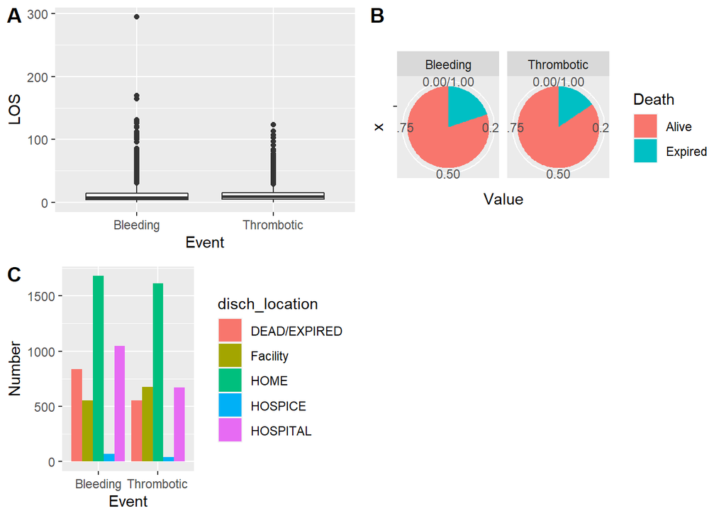

```r
require(ggpubr)
ggarrange(box_age, pie_death, bar_disch, nrow = 2,ncol = 2, labels = c("A","B","C"))
```

```r
#ggsave("myplot.png")
```

### Results

This section shows the results of cohort analysis of the two categories with the plots and codes used to get them.

#### Topic Modeling

As a popular unsupervised method, we used topic Modeling with Latent Dirichlet Allocation (LDA) for discovering latent semantic properties in our cohorts’ notes.

```r
# Merging two tables that represent the two cohorts of thrombotic and bleeding by the two indexes to build the cohort data for the topic modeling

icd_notes_thrombo <- inner_join(x = out_thrombo, y = newicd_thrombo, by = c("SUBJECT_ID", "HADM_ID"))
icd_notes_bleed <- inner_join(x = out_bleed, y = newicd_bleed, by = c("SUBJECT_ID", "HADM_ID"))
```

##### Document Cleaning

Neccesary steps before apply the LDA model

1. Creating the corpus
2. Cleaning the corpus (removing punctuations, numbers, stop words, white spaces, etc.)
3. getting rid of very commons words in the text

```r
#Thrombo

notes_document_t <- icd_notes_thrombo%>% select(ROW_ID.x, TEXT)%>% rename(doc_id = ROW_ID.x, text = TEXT)

notes_corpus_t <- Corpus(DataframeSource(notes_document_t))

notes_corpus_t <- tm_map(notes_corpus_t, removePunctuation, preserve_intra_word_dashes = TRUE)

notes_corpus_t <- tm_map(notes_corpus_t, removeNumbers)

notes_corpus_t <- tm_map(notes_corpus_t, tolower)


custom_stopwords <- read.csv("stopwords.csv", header = FALSE)
custom_stopwords <- as.character(custom_stopwords$V1)
custom_stopwords <- c(custom_stopwords, stopwords())


#english_stopwords <- readLines("https://slcladal.github.io/resources/stopwords_en.txt", encoding = "UTF-8")

notes_corpus_t <- tm_map(notes_corpus_t, removeWords, custom_stopwords)

#notes_corpus_t <- tm_map(notes_corpus_t, stemDocument, language = "en")

notes_corpus_t <- tm_map(notes_corpus_t, stripWhitespace)


#Bleeding

notes_document_b <- icd_notes_bleed%>% select(ROW_ID.x, TEXT)%>% rename(doc_id = ROW_ID.x, text = TEXT)

notes_corpus_b <- Corpus(DataframeSource(notes_document_b))

notes_corpus_b <- tm_map(notes_corpus_b, removePunctuation, preserve_intra_word_dashes = TRUE)

notes_corpus_b <- tm_map(notes_corpus_b, removeNumbers)

notes_corpus_b <- tm_map(notes_corpus_b, tolower)


notes_corpus_b <- tm_map(notes_corpus_b, removeWords, custom_stopwords)

#notes_corpus_b <- tm_map(notes_corpus_b, removeWords, c(english_stopwords, "admission","discharge","doctor", "hospital", "job", "number", "last", "first", "name", "namepattern", "date", "telephon", "fax", "patient", "left", "right", "man", "woman", "status", "note", "clip", "report", "radiology", "reason", "chest", "report", "medic", "radilog", "admit", "year", "final", "impress", "chang", "unchang", "find", "histori", "present", "portabl", "contrast", "day", "daily", "note", "show", "time", "Portal", "main", "patent", "show", "medic", "medical", "medics", "patient", "patients", "historics", "historic", "historical", "histori", "stable", "stabl", "stables", "start", "stop", "week", "notes", "hour", "hct-", "wbc-", "family", "disp", "rbc-", "hgb-", "tube",  "capsul","insulin", "mcv-", "initi", "glucose-", "ct-", "rdw-", "start", "call", "Chang", "change", "changes", "changed", "indentify", "identifi", "identification", "procedur", "procedure", "procedures", "hct-", "admit", "admits", "imag", "images", "image", "diagnosi", "diagnosis", "post", "numer", "wbc-", "rbc-", "condit", "hgb-", "mcv-", "rdw-", "unchang", "unchanged", "impress", "impression", "mchc-", "eval", "evaluate", "evaluation", "mch-", "initi", "initial", "hour", "hours", "level", "egd", "line", "imag", "imags", "hct", "need", "side", "later", "ct-"))

#notes_corpus_b <- tm_map(notes_corpus_b, stemDocument, language = "en")


notes_corpus_b <- tm_map(notes_corpus_b, stripWhitespace)
```

##### Building Document Term Matrix

In the LDA model, we need to build a Document Term Matrix (DTM) that contains the number of term occurrences per document. The rows of the DTM represent the documents, and the columns represent the whole vocabulary. Setting a minimum frequency would save overwhelming the system’s memory.

```r
#Thrombo

min_freq_t <- 100
notes_corpus_t.dtm <- DocumentTermMatrix(notes_corpus_t, control = list(bounds = list(global = c(min_freq_t, Inf))))

rowTotals_t <- apply(notes_corpus_t.dtm , 1, sum)

notes_corpus_t.dtm   <- notes_corpus_t.dtm[rowTotals_t> 0, ]

dim(notes_corpus_t.dtm)
```

```
## [1] 8430 3491
```

```r
# Bleeding
min_freq_b <- 100
notes_corpus_b.dtm <- DocumentTermMatrix(notes_corpus_b, control = list(bounds = list(global = c(min_freq_b, Inf))))

rowTotals_b <- apply(notes_corpus_b.dtm , 1, sum)

notes_corpus_b.dtm   <- notes_corpus_b.dtm[rowTotals_b> 0, ]

dim(notes_corpus_b.dtm)
```

```
## [1] 27742  4831
```

##### Term Frequency

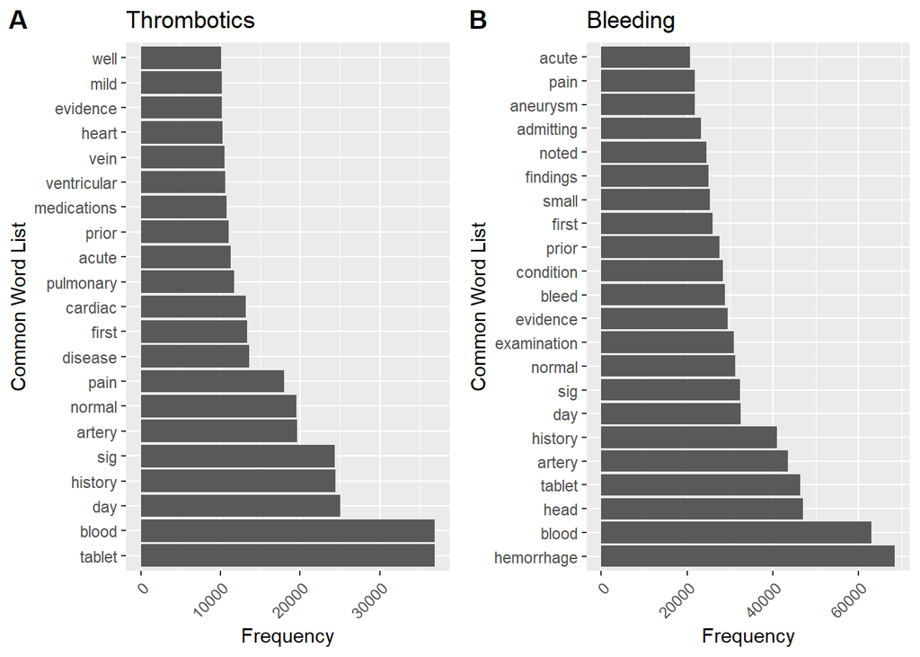

```r
#Thrombo

freq_t <- sort(colSums(as.matrix(notes_corpus_t.dtm)), decreasing=TRUE)

word.freq_t <- data.frame(word_t = names(freq_t), freq = freq_t)

Tplot<- ggplot(subset(word.freq_t, freq_t > 10000), aes(x = reorder(word_t, -freq), y = freq)) +
  geom_bar(stat = "identity") + theme(axis.text.x = element_text(angle = 45, hjust = 1)) + coord_flip() + labs(title = "Thrombotics")+
  labs(x="Common Word List", y="Frequency")


# Bleeding

freq_b <- sort(colSums(as.matrix(notes_corpus_b.dtm)), decreasing=TRUE)

word.freq_b <- data.frame(word_b = names(freq_b), freq = freq_b)

Bplot <- ggplot(subset(word.freq_b, freq_b > 20000), aes(x = reorder(word_b, -freq), y = freq)) +
  geom_bar(stat = "identity") + theme(axis.text.x = element_text(angle = 45, hjust = 1)) + coord_flip() + labs(title = "Bleeding")+
  labs(x="Common Word List", y="Frequency")

library("ggpubr")

figure <- ggarrange(Tplot, Bplot,
                    labels = c("A", "B"))
figure
```

```r
#ggsave("myplot2.png")
```

##### Word Cloud

[figure not shown]

```r
#set.seed(2000)


par(mfrow=c(1,2))


wordcloud(words = names(freq_t), freq = freq_t, min.freq = 10000, max.words=50,  random.order=FALSE, rot.per=0.35, random.color = FALSE, colors= c("indianred1","indianred2","indianred3","indianred"))

wordcloud(words = names(freq_b), freq = freq_b, min.freq = 10000, max.words=40, random.order=FALSE, rot.per=0.35, random.color = FALSE, colors= c("lightsteelblue1","lightsteelblue2","lightsteelblue3","lightsteelblue"))
```

```r
#ggsave("myplot5.png")
```

##### LDA topic Modelling

To apply the LDA model, various parameters need to be set, e.g. number of topics, the LDA methods, iterations,etc.

```r
K <- 20
set.seed(1000)
# Gibbs sampling
topicModel_t <- LDA(notes_corpus_t.dtm, K, method="Gibbs", control=list(iter = 500, verbose = 50))
```

```
## K = 20; V = 3491; M = 8430
## Sampling 500 iterations!
## Iteration 50 ...
## Iteration 100 ...
## Iteration 150 ...
## Iteration 200 ...
## Iteration 250 ...
## Iteration 300 ...
## Iteration 350 ...
## Iteration 400 ...
## Iteration 450 ...
## Iteration 500 ...
## Gibbs sampling completed!
```

```r
topicModel_b <- LDA(notes_corpus_b.dtm, K, method="Gibbs", control=list(iter = 500, verbose = 50))
```

```
## K = 20; V = 4831; M = 27742
## Sampling 500 iterations!
## Iteration 50 ...
## Iteration 100 ...
## Iteration 150 ...
## Iteration 200 ...
## Iteration 250 ...
## Iteration 300 ...
## Iteration 350 ...
## Iteration 400 ...
## Iteration 450 ...
## Iteration 500 ...
## Gibbs sampling completed!
```

```r
topicModel_t
```

```
## A LDA_Gibbs topic model with 20 topics.
```

```r
topicModel_b
```

```
## A LDA_Gibbs topic model with 20 topics.
```

##### Topic Terms

```r
terms(topicModel_t, 10)
```

```
##       Topic 1      Topic 2         Topic 3     Topic 4        Topic 5      Topic 6       Topic 7       Topic 8      Topic 9    Topic 10      Topic 11       Topic 12          Topic 13   Topic 14      Topic 15     Topic 16    Topic 17    Topic 18    Topic 19  Topic 20
##  [1,] "catheter"   "normal"        "pain"      "head"         "pain"       "portal"      "history"     "renal"      "history"  "intubated"   "small"        "cardiac"         "blood"    "negative"    "day"        "lower"     "pulmonary" "artery"    "tablet"  "artery"
##  [2,] "identifier" "valve"         "history"   "hemorrhage"   "history"    "vein"        "normal"      "failure"    "lasix"    "respiratory" "pelvis"       "coronary"        "plt"      "culture"     "blood"      "veins"     "pleural"   "carotid"   "sig"     "surgery"
##  [3,] "numeric"    "ventricular"   "bleeding"  "acute"        "cardiac"    "liver"       "bilaterally" "units"      "cxr"      "history"     "abdomen"      "lad"             "wbc-"     "blood"       "history"    "vein"      "effusion"  "aneurysm"  "day"     "coronary"
##  [4,] "performed"  "aortic"        "bleed"     "brain"        "heart"      "hepatic"     "intact"      "disease"    "chf"      "failure"     "fluid"        "cath"            "rbc-"     "infection"   "rate"       "femoral"   "lung"      "arteries"  "refills" "graft"
##  [5,] "artery"     "mitral"        "abdominal" "intracranial" "denies"     "thrombosis"  "pain"        "acute"      "edema"    "continued"   "bowel"        "disease"         "hgb-"     "vancomycin"  "pressure"   "extremity" "lobe"      "cta"       "release" "history"
##  [6,] "sheath"     "regurgitation" "bowel"     "infarction"   "metoprolol" "ascites"     "fracture"    "chronic"    "setting"  "however"     "noted"        "stenosis"        "mcv-"     "urine"       "coronary"   "dvt"       "bilateral" "cerebral"  "tablets" "bypass"
##  [7,] "first"      "wall"          "cancer"    "mass"         "location"   "flow"        "head"        "diabetes"   "baseline" "hypotension" "unremarkable" "stent"           "glucose-" "cultures"    "heart"      "thrombus"  "effusions" "anterior"  "every"   "stitle"
##  [8,] "advanced"   "systolic"      "denies"    "findings"     "prior"      "cirrhosis"   "showed"      "creatinine" "nstemi"   "intubation"  "evidence"     "catheterization" "rdw-"     "gram"        "artery"     "venous"    "edema"     "posterior" "capsule" "disease"
##  [9,] "wire"       "mildly"        "nausea"    "evidence"     "aspirin"    "gallbladder" "noted"       "scale"      "days"     "shock"       "free"         "artery"          "mchc-"    "fluid"       "disease"    "condition" "upper"     "internal"  "needed"  "service"
## [10,] "service"    "mild"          "blood"     "frontal"      "review"     "ultrasound"  "weakness"    "kidney"     "copd"     "noted"       "cta"          "pain"            "mch-"     "antibiotics" "hematocrit" "flow"      "lower"     "stenosis"  "delayed" "cardiac"
```

```r
terms(topicModel_b, 10)
```

```
##       Topic 1            Topic 2      Topic 3       Topic 4      Topic 5      Topic 6        Topic 7       Topic 8    Topic 9       Topic 10     Topic 11  Topic 12      Topic 13       Topic 14       Topic 15      Topic 16       Topic 17     Topic 18           Topic 19    Topic 20
##  [1,] "hemorrhage"       "catheter"   "bleeding"    "artery"     "brain"      "portable"     "examination" "blood"    "pain"        "blood"      "tablet"  "history"     "abdomen"      "aneurysm"     "normal"      "head"         "hematoma"   "hemorrhage"       "evidence"  "negative"
##  [2,] "head"             "identifier" "history"     "carotid"    "mass"       "placement"    "admitting"   "plt"      "intact"      "day"        "sig"     "bilaterally" "pelvis"       "cta"          "aortic"      "acute"        "subdural"   "subarachnoid"     "normal"    "failure"
##  [3,] "edema"            "numeric"    "bleed"       "identifier" "mri"        "pleural"      "bleed"       "wbc-"     "bilaterally" "history"    "day"     "noted"       "small"        "artery"       "valve"       "air"          "prior"      "head"             "bilateral" "renal"
##  [4,] "shift"            "performed"  "pain"        "numeric"    "lesion"     "pulmonary"    "condition"   "rbc-"     "headache"    "pressure"   "needed"  "weakness"    "liver"        "head"         "ventricular" "sinuses"      "small"      "frontal"          "vein"      "continued"
##  [5,] "intraparenchymal" "artery"     "blood"       "aneurysm"   "head"       "lung"         "findings"    "hgb-"     "history"     "hematocrit" "every"   "intubated"   "fluid"        "cerebral"     "mild"        "cells"        "interval"   "lateral"          "fracture"  "culture"
##  [6,] "large"            "stitle"     "denies"      "internal"   "lobe"       "effusion"     "comparison"  "mcv-"     "normal"      "showed"     "capsule" "showed"      "bowel"        "arteries"     "mitral"      "structures"   "study"      "intraventricular" "lower"     "due"
##  [7,] "lateral"          "first"      "ulcer"       "common"     "underlying" "tip"          "prior"       "rdw-"     "tablet"      "care"       "release" "neurology"   "abdominal"    "subarachnoid" "systolic"    "intracranial" "noted"      "ventricles"       "spine"     "fluid"
##  [8,] "midline"          "advanced"   "colonoscopy" "vertebral"  "mra"        "pneumothorax" "study"       "mchc-"    "sig"         "rate"       "pain"    "intact"      "free"         "anterior"     "mildly"      "hemorrhage"   "collection" "ventricular"      "findings"  "infection"
##  [9,] "mass"             "bleeding"   "normal"      "cerebral"   "area"       "atelectasis"  "interval"    "mch-"     "day"         "unit"       "refills" "stroke"      "unremarkable" "evidence"     "moderate"    "sinus"        "fluid"      "size"             "veins"     "respiratory"
## [10,] "ventricle"        "sheath"     "home"        "order"      "region"     "condition"    "assess"      "glucose-" "first"       "continued"  "tablets" "speech"      "large"        "recons"       "cardiac"     "white"        "size"       "interval"         "mild"      "urine"
```

```r
library(tidytext)
topicModel_td_t <- tidy(topicModel_t)
topicModel_td_t
```

```
## # A tibble: 69,820 x 3
##    topic term         beta
##    <int> <chr>       <dbl>
##  1     1 -fib  0.00000101
##  2     2 -fib  0.000000497
##  3     3 -fib  0.000000523
##  4     4 -fib  0.000000616
##  5     5 -fib  0.0000418
##  6     6 -fib  0.000000986
##  7     7 -fib  0.000000704
##  8     8 -fib  0.0000216
##  9     9 -fib  0.000390
## 10    10 -fib  0.000000654
## # ... with 69,810 more rows
```

```r
topicModel_td_b <- tidy(topicModel_b)
topicModel_td_b
```

```
## # A tibble: 96,620 x 3
##    topic term         beta
##    <int> <chr>       <dbl>
##  1     1 abd   0.000000363
##  2     2 abd   0.000000399
##  3     3 abd   0.000931
##  4     4 abd   0.000000265
##  5     5 abd   0.000000371
##  6     6 abd   0.000000384
##  7     7 abd   0.000000498
##  8     8 abd   0.00246
##  9     9 abd   0.000833
## 10    10 abd   0.000000270
## # ... with 96,610 more rows
```

```r
top_terms_t <- topicModel_td_t %>%
  group_by(topic) %>%
  top_n(5, beta) %>%
  ungroup() %>%
  arrange(topic, -beta)
top_terms_t
```

```
## # A tibble: 100 x 3
##    topic term          beta
##    <int> <chr>        <dbl>
##  1     1 catheter    0.0415
##  2     1 identifier  0.0345
##  3     1 numeric     0.0342
##  4     1 performed   0.0185
##  5     1 artery      0.0152
##  6     2 normal      0.0462
##  7     2 valve       0.0440
##  8     2 ventricular 0.0435
##  9     2 aortic      0.0430
## 10     2 mitral      0.0327
## # ... with 90 more rows
```

```r
top_terms_b <- topicModel_td_b %>%
  group_by(topic) %>%
  top_n(5, beta) %>%
  ungroup() %>%
  arrange(topic, -beta)
top_terms_b
```

```
## # A tibble: 100 x 3
##    topic term               beta
##    <int> <chr>             <dbl>
##  1     1 hemorrhage       0.0928
##  2     1 head             0.0423
##  3     1 edema            0.0344
##  4     1 shift            0.0326
##  5     1 intraparenchymal 0.0324
##  6     2 catheter         0.0255
##  7     2 identifier       0.0231
##  8     2 numeric          0.0229
##  9     2 performed        0.0199
## 10     2 artery           0.0172
## # ... with 90 more rows
```

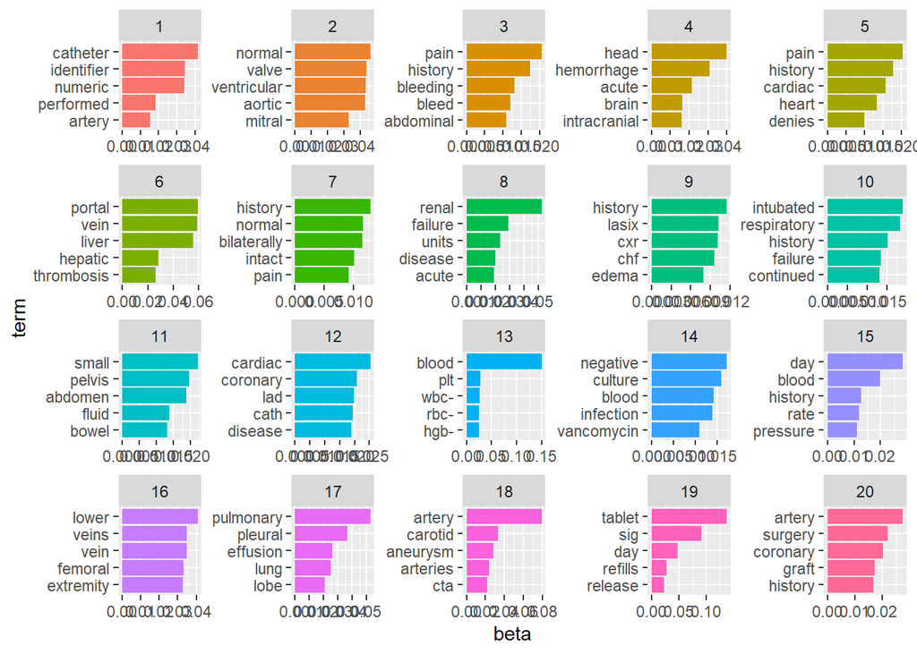

```r
top_terms_t %>%
  mutate(topic = factor(topic),
         term = reorder_within(term, beta, topic)) %>%
  ggplot(aes(term, beta, fill = topic)) +
  geom_bar(alpha = 1.0, stat = "identity", show.legend = FALSE) +
  scale_x_reordered() +
  facet_wrap(~ topic, scales = "free", ncol = 5) +
  coord_flip()
```

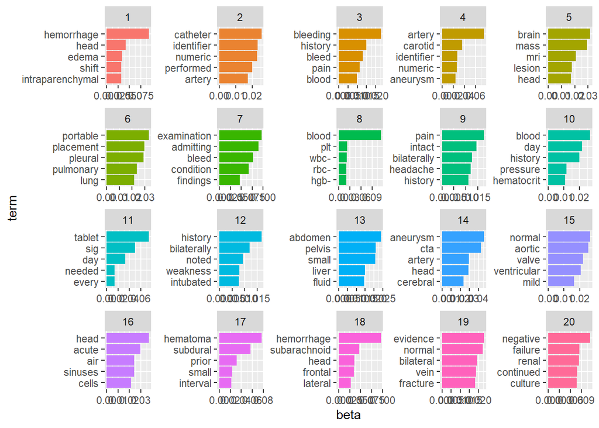

```r
top_terms_b %>%
  mutate(topic = factor(topic),
         term = reorder_within(term, beta, topic)) %>%
  ggplot(aes(term, beta, fill = topic)) +
  geom_bar(alpha = 1.0, stat = "identity", show.legend = FALSE) +
  scale_x_reordered() +
  facet_wrap(~ topic, scales = "free", ncol = 5) +
  coord_flip()
```

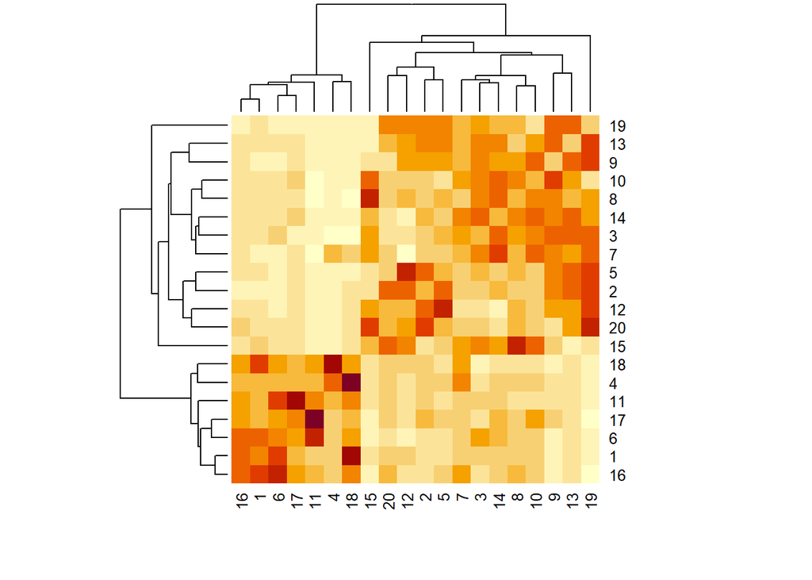

```r
library(gplots)
cor_topic_t = cor(posterior(topicModel_t)$topics)
diag(cor_topic_t) = 0
heatmap(cor_topic_t)
```

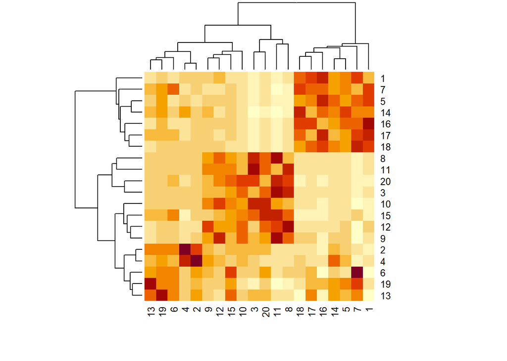

```r
cor_topic_b = cor(posterior(topicModel_b)$topics)
diag(cor_topic_b) = 0
heatmap(cor_topic_b)
```

```r
#ggsave("myplot5.png")
```

```r
# the figure for coherence and prevalence score in the Topic Model
```

```r
# Dendogram (distance between 2 probability vectors)
```

```r
#text_bigrams <- notes_document %>% tidytext::unnest_tokens(bigram, text, token = "ngrams", n = 2)

#bigrams_sep <- text_bigrams %>% separate(bigram, c("word1", "word2"), sep = " ")
```

```r
#AFINN <- tidytext::get_sentiments("afinn")

#not_set <- bigrams_sep %>% filter(word1 == "not") %>% inner_join(AFINN, by = c(word2 = "word")) %>% count(word2, value, sort = TRUE)


#not_set %>% mutate(contribution = n * value) %>% arrange(desc(abs(contribution))) %>% head(20) %>% mutate(word2 = reorder(word2, contribution)) %>%
#  ggplot(aes(n * value, word2, fill = n * value > 0)) + geom_col(show.legend = FALSE) + labs(x = "Sentiment value * number of occurrences",
#       y = "Words preceded by \"not\"")


#negation_words <- c("not", "no", "never", "without")

#negated_words <- bigrams_separated %>%
#  filter(word1 %in% negation_words) %>%
#  inner_join(AFINN, by = c(word2 = "word")) %>%
#  count(word1, word2, value, sort = TRUE)
```

#### Cohort Analysis

variable in different tables are analyzed. All codes are shown here.

```r
#all_codes <- c("4320", "4321", "430", "431", "72992","37923", "42979", "4230", "4230", "41512", "452", "45351", "45386", "45382", "45382", "4536", "4532", "4533", "4510", "4358", "43391", "36234", "4359", "44409", "44409", "41181", "42979", "41091", "41071", "44481", "5789", "53501", "53100", "53110", "53120", "53130", "53140", "53150", "53160", "53200", "53210", "53220", "53230", "53240", "53250", "53260", "53270", "53300", "53310", "53320", "53340", "53350", "53360", "53400", "53410", "53420", "53440", "53450", "53460", "4560", "56212", "56213", "56213", "5695", "56202", "56203", "56201", "56203", "5693", "56881")

#newicd_notes <- subset(icdcodes, ICD9_CODE %in% all_codes)
#icd_notes <- inner_join(x = note_new_clipped, y = newicd_notes, by = c("SUBJECT_ID", "HADM_ID"))
```

##### Cohort Analysis - age

```r
#admission_sub = Admissions[Admissions$SUBJECT_ID %in% newicd_notes$SUBJECT_ID & Admissions$HADM_ID %in% newicd_notes$HADM_ID,]
#admission_sub = admission_sub %>% distinct(SUBJECT_ID, .keep_all = TRUE)
#admission_sub$ADMITTIME = as.POSIXlt(as.character(admission_sub$ADMITTIME), format = "%Y-%m-%d %H:%M:%S")
#admission_sub$DISCHTIME = as.POSIXlt(as.character(admission_sub$DISCHTIME), format = "%Y-%m-%d %H:%M:%S")
#admission_sub$los = difftime( admission_sub$DISCHTIME, admission_sub$ADMITTIME, units = "days")
#admission_sub$birth = NA

#for (i in 1:nrow(admission_sub)){
  #print(i)
#  admission_sub$birth[i] = as.character(patients$DOB[patients$SUBJECT_ID == admission_sub$SUBJECT_ID[i]])
#}
#admission_sub$birth = as.POSIXlt(admission_sub$birth, format = "%Y-%m-%d %H:%M:%S")
#admission_sub$age = NA
#admission_sub$age = difftime(admission_sub$ADMITTIME, admission_sub$birth, units = "days")/365.25
#admission_sub$age = as.numeric(admission_sub$age)
#hist(as.numeric(admission_sub$age))

#length(which(admission_sub$age>100))
## 550 patients had age >100
```

```r
#admission_sub$subtype_binary = NA
#bleeding <- c("4320", "4321", "430", "431","72992","37923","42979", "4230","5789", "53501", "53100", "53110", "53120", "53130", "53140", "53150", "53160", "53200",
#                            "53210", "53220", "53230", "53240", "53250", "53260", "53270", "53300", "53310", "53320",
#                             "53340", "53350", "53360", "53400", "53410", "53420", "53440", "53450", "53460", "4560",
#                             "56212", "56213", "56213", "5695", "56202", "56203", "56201", "56203", "5693", "56881")

#thrombotic <- c("41512","452", "45351", "45386", "45382", "45382", "4536", "4532", "4533", "4510","4358", "43391", "36234", "4359","44409", "44409", "41181", "42979", "41091", "41071", "44481")




#for(i in 1:nrow(admission_sub)){

#  temp = icdcodes[which(icdcodes$SUBJECT_ID == admission_sub$SUBJECT_ID[i] &
#                                 icdcodes$HADM_ID == admission_sub$HADM_ID[i]),]
#  if(any(temp$ICD9_CODE %in% bleeding)){
#    admission_sub$subtype_binary[i] = paste(admission_sub$subtype_binary[i], "bleeding", sep = "_")
#  }
#  if(any(temp$ICD9_CODE %in% thrombotic )){
#    admission_sub$subtype_binary[i] = paste(admission_sub$subtype_binary[i], "thrombotic ", sep = "_")
#  }

#}



#admission_sub$subtype_binary = gsub("NA_","",admission_sub$subtype_binary)
#table(admission_sub$subtype_binary)
```

```r
#prescriptions_sub = prescriptions[prescriptions$SUBJECT_ID %in% admission_sub$SUBJECT_ID &  prescriptions$HADM_ID %in% admission_sub$HADM_ID,]
#prescriptions_sub$label = NA
#for(i in 1:nrow(prescriptions_sub)){
#  prescriptions_sub$label[i] = admission_sub$subtype_binary[admission_sub$SUBJECT_ID == prescriptions_sub$SUBJECT_ID[i] &
#                                                              admission_sub$HADM_ID == prescriptions_sub$HADM_ID[i]]
#}
```

### Limitations and Future Work

This project study the thrombotic and bleedings evenst for the patinets admitted based on the MIMIC-III dataset. The analysis can take a step further by looking at the different categories of the thrombotic and bleeding events. Some of the most common subcategories and their respective ICD-9 codes are shown below.

#### Events’ Subcategories codes

```r
#neurological_bleeding <- c("4320", "4321", "430", "431")
#Musculoskeletal_bleeding <- c("72992")
#Ocular_bleeding <- c("37923")
#Cardiac_bleeding <- c("42979", "4230")
#Genitourinary_bleeding <- c("4230")
#pulmonary_thrombotic <- c("41512")
#extremity_thrombotic <- c("452", "45351", "45386", "45382", "45382", "4536", "4532", "4533", "4510")
#neurological_thrombotic <- c("4358", "43391", "36234", "4359")
#cardiovascular_thrombotic <-  c("44409", "44409", "41181", "42979", "41091", "41071", "44481")
#Gastrointestinal_bleeding <- c("5789", "53501", "53100", "53110", "53120", "53130", "53140", "53150", "53160", "53200",
#                            "53210", "53220", "53230", "53240", "53250", "53260", "53270", "53300", "53310", "53320",
#                             "53340", "53350", "53360", "53400", "53410", "53420", "53440", "53450", "53460", "4560",
#                            "56212", "56213", "56213", "5695", "56202", "56203", "56201", "56203", "5693", "56881")
```

### References

MIMIC-III, a freely accessible critical care database. Johnson AEW, Pollard TJ, Shen L, Lehman L, Feng M, Ghassemi M, Moody B, Szolovits P, Celi LA, and Mark RG. Scientific Data (2016). DOI: 10.1038/sdata.2016.35. Available at: http://www.nature.com/articles/sdata201635